# RigidBody2D

# RigidBody2D moves with physics

The `RigidBody2D` node lets you move objects using physics with minimal coding required. You apply forces, impulses, and torque to move objects in your scene.

`RigidBody2D` handles gravity and collisions out of the box, so you get up and running with minimal coding.

This is in contrast to a `KinematicBody2D`, which you move and rotate by hand. Choosing between these two is a tradeoff between precise controls and automated physics.

`RigidBody2D` is incredibly versatile. You can use it for bouncing grenades, push-able blocks, destructible terrain, and much more.

In this guide, you will learn:

- How to create top-down and side-scrolling player controllers with `RigidBody2D`.
- How to push bodies with forces in an explosion.
- How to set up a scene to simulate gravity and collisions.
- How to change the mode of a `RigidBody2D` for breaking a ship into debris with physics.

Contents:

- Setting up a RigidBody2D
- RigidBody2D key features
  - Forces and impulses
  - The node’s four modes
  - Mass, weight, and gravity scale
  - Reporting contacts
  - Physics materials
- How to use a RigidBody2d in practice
  - Making a top-down player controller
  - Making a side-scrolling player controller
  - Make an explosion with forces
  - Creating structures that collapse and fall over
  - Turning bodies into debris with the mode property
  - Exploding polygons with code using Delaunay triangulation
- Your questions
  - When should I use a RigidBody2D over a KinematicBody2D?
  - How can I make something float?
  - What is sleeping?
  - Can I scale my rigid body?
  - How can I figure out if a body will have a collision?

## Setting up a RigidBody2D

In Godot, physics nodes need a collision shape or polygon as a child to define their collider.

This is true of Area2D, KinematicBody2D, `StaticBody2D`, and in our case, `RigidBody2D`.

The collision shape lets them figure out when they are touching or overlapping other bodies.

You need three components for a `RigidBody2D` to work:

1. The `RigidBody2D` node itself, which will handle forces applied to itself.
2. One or more `CollisionShape2D` or `CollisionPolygon2D` that define the polygon(s) of the `RigidBody2D`.
3. Each collision shape has a shape resource associated with them (probably a `RectangleShape2D` or a `CircleShape2D`, but it could also be another `Shape2D`), while the collision polygon has an array of points.

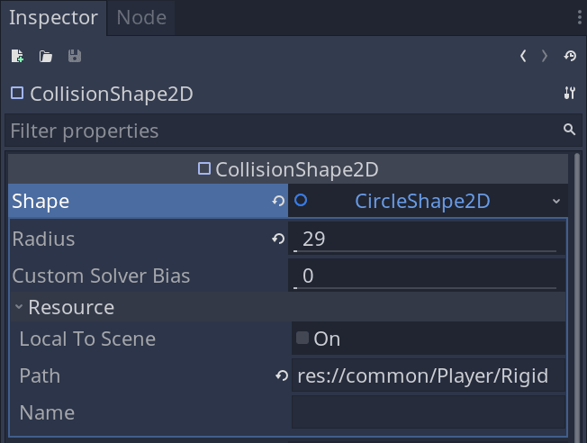

You will also want to add either a texture or a polygon to represent the `RigidBody2D`. Standard options for that are `Sprite`, `AnimatedSprite`, or `Polygon2D`.

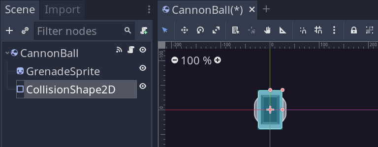

You can also enable *Visible Collision Shapes* in the *Debug* dropdown menu to see the colliders when testing the game.

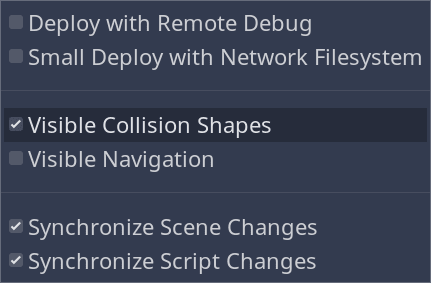

## RigidBody2D key features

The `RigidBody2D` has many properties that control how it should react to forces. A lot of your setup will involve tweaking its properties in the editor.

### Forces and impulses

Technically, you could apply the same impulse every frame with a time delta to achieve the same effect as `add_force()`. However, it requires more code and care, which is why both functions exist.

#### Applying forces and impulses

You can apply a force with the `add_central_force()` and `add_force()` methods.

A central force only moves a body from its center of mass while `add_force()` lets you move the body from any local position.

If you offset the force from its center of mass with `add_force()`, the node may rotate.

To apply an impulse, you want to call `apply_central_impulse()` or `apply_impulse()`. They work the same as force-related methods, except they only apply a one-time impulse.

**Note:** Applying impulses every frame will make your force framerate-dependent. If the player’s framerate goes down, your bodies’ motions will slow down too.

That’s why you only want to use those methods for one-time impulses, like explosions.

Alternatively, you can multiply your impulse by the time since the last physics update when overriding the `_integrate_forces()` virtual method. The function provides a `state.step` value, the time interval between two physics ticks.

You’ll see below how we use `state.step` in concrete use cases.

#### Overriding forces

There are some cases when you want to cancel out or manage the overall force moving your body by yourself.

Imagine an enemy casts a fireball at you, and you use a spell to grab it in mid-air and throw it back at them.

To reset forces, you can change the value of the `applied_force` property.

```
extends RigidBody2D

func cancel_forces() -> void:
    applied_force = Vector2.ZERO
```

Finally, note the body’s *Mass* property affects how forces work. The higher the *Mass*, the more force you need to move.

#### Applying rotational forces

While the `add_force()` and `apply_impulse()` methods can cause a body to rotate on top of moving, you may want only to apply a rotational force at times, also called torque.

You can use that to make a wheel turn, for instance.

To apply constant torque, use the `add_torque()` method. For a one-time rotational impulse, you’ll use `apply_torque_impulse()` instead.

The *Inertia* property of a `RigidBody2D` is to torque what *Mass* is to forces: the higher the *Inertia*, the more torque it takes to rotate the body.

Forces are complex and warrant experimenting with. They are designed to interact with each other and joined to create complex behaviors.

#### Integrating forces

Unlike with other physics nodes, you don’t want to directly change the `position` of a `RigidBody2D` inside `_physics_process()`. As the physics engine applies forces to it, you need to be careful when modifying the body’s state manually.

To do so, you want to override and use the `_integrate_forces()` virtual function. This lets all the forces acting on a body combine properly with changes in `linear_velocity`.

The function contains a `Physics2DDirectBodyState` object called `state`, which includes information on the state of your rigid body. You can call functions on this object or access variables like `linear_velocity` to determine how fast the body is moving.

Accessing properties using this `state` ensures they are up to date following collisions, forces and impulses.

You’ll see some examples in this guide.

### The node’s four modes

A `RigidBody2D` has four modes that change its general behavior:

- By default, it uses the *Rigid* mode. In this mode, the body falls under the effect of and pushes other bodies it collides with.
- The *Static* mode makes your `RigidBody2D` completely stationary. It is useful when enabling and disabling doors, locking objects in place.
- The *Character* mode is ideal for player characters. It behaves similarly to rigid mode but won’t rotate on its own. This ensures a player’s character remains upright.
- Finally, *Kinematic* is a helpful mode for manually making changes to a body. This mode makes the `RigidBody2D` work similarly to a `KinematicBody2D`: it doesn’t integrate forces, and you have to change its position manually. Use it to take manual control over a character or in cases where you need to teleport the body to a precise location.

You can control the active mode using the node’s *Mode* property.

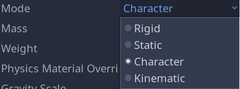

You can switch mode on the fly depending on your needs. For instance, a character can go from the *Character* mode to *Rigid* when dying, causing it to get pushed around by other bodies.

### Mass, weight, and gravity scale

Three properties greatly affect how a `RigidBody2D` moves:

1. *Mass* represents how massive the object is.
   - The higher the value, the more force you need to move it.
   - On the other hand, setting it to a low number makes an object easy to knock about.
   - The body’s center of mass is at the node’s origin.
2. *Weight* is *Mass* multiplied by the *Default Gravity*, so updating the *Mass* updates its *Weight* in turn.
3. The *Default Gravity* is a project-wide setting.
   - The physics engine applies it to every `RigidBody2D` to make them move down towards the ground.
   - You can change it by going to *Project Settings -> Physics* -> 2D -> *Default Gravity*.

Godot’s default gravity is low, set to `9.8`.

If you want objects to fall faster, you will need to increase this in project settings. You can also increase the gravity scales on your `RigidBody2D` itself.

Note that *Mass* and *Weight* do not affect the speed at which an object falls.

This is the same as the real world: all objects fall at the same speed. [See the hammer and feather experiment on the Moon](https://youtu.be/KDp1tiUsZw8).

You either need to increase gravity or apply an extra downwards force to make an object fall faster. We’ll see how to apply forces in the examples below.

### Reporting contacts

`RigidBody2D` has four convenient signals to detect and react when it hit something.

The main two are `body_entered` and `body_exited`. They are and work similarly to `Area2D`’s signals: when a collision happens, the callback tells you what you hit.

You can use them to trigger an explosion when touching a mine, to inflict damage, and more.

However, by default, rigid bodies don’t report collisions and points of contact for performance reasons.

The collisions happen; the node just won’t emit signals.

If you want the node to emit these signals, there are two steps:

1. Turn on *Contact Monitor* to turn on collision reports.
2. Increase *Contacts Reported* to the number of contacts you want to pay attention to. Once the node emitted this number of signals, it will ignore the rest in that frame.

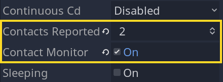

As a rule of thumb, you can set contacts reported relatively high if you are dealing with one object.

However, if you have many objects detecting collisions, you want to limit the reported contacts for performance.

You’ll have to play with the *Contacts Reported* property in your game to see what works for you.

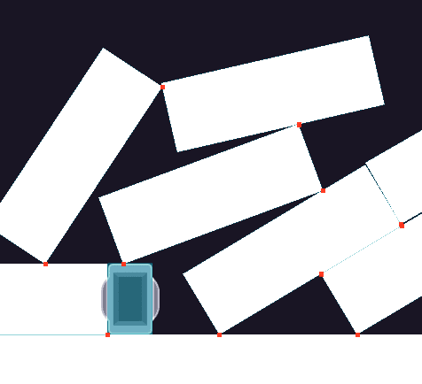

### Physics materials

Physics materials let you fine-tune how forces affect rigid bodies.

You can save a `PhysicsMaterial` as a resource and assign it to any `RigidBody2D`’s *Physics Material Override* to reuse it.

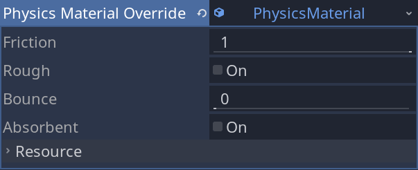

The properties you can control are *Friction*, *Rough*, *Bounce*, and *Absorbent*:

- *Friction* determines how much an object slows when colliding with another. It can be useful to set *Friction* low on a player character, or the player will move slower on the floor due to gravity.
- *Rough* is a toggle that determines how bodies with different frictions interact. If a body is rough, both colliding bodies will use the highest friction. In short, this lets you slow down objects that collide with this body.
- *Bounce* determines how much momentum is lost in a collision. With `0` bounce, an object will stop immediately. A bounce of `1.0` means the body will change direction instead of losing momentum. Think of a basketball hitting the floor versus wet tissue paper.
- *Absorbent* is a toggle that determines how bodies with different `bounce` interact. The bounciness of the absorbent body is subtracted from the colliding body. In short, a bouncy object colliding with an absorbent body will bounce less.

## How to use a RigidBody2d in practice

### Making a top-down player controller

If you want the player to get knocked about by the environment, you should consider a `RigidBody2D`. You can simulate collisions very easily at the cost of having less control of the player compared to a `KinematicBody2D`.

In this example, we’ll make a ship that moves smoothly in space with only a few lines of code. This approach leads to nice arcade controls with some drag.

[figure not shown]

For this kind of controller, you generally want control over how the character rotates. You can set the `RigidBody2D`’s *Mode* to *Character* to do so.

For the collision shape, circles and rectangles tend to work best: they’re easiest for the player to feel and understand intuitively.

In this demo, we used a circle for collisions.

[figure not shown]

To make the character’s control feel tight, you can play with *Linear -> Damp* and set it to a value greater than `1.0`. It makes the body slow down automatically when you don’t apply forces and smoothly come to a stop. The higher the value, the faster it stops.

To move the character, we can directly set the force that moves it every frame.

```
export var move_force_amplitude := 6000.0

func _physics_process(delta: float) -> void:
    # We get the player's input direction as a 2D vector.
    var direction := Vector2(
        Input.get_action_strength("move_right") - Input.get_action_strength("move_left"),
        Input.get_action_strength("move_down") - Input.get_action_strength("move_up")
    ).normalized()

    # We directly update the total applied forces to the node.
    # If the player presses a direction key, we apply a force to the ship.
    # If the player does not press in any direction, the multiplication resets
    # the force to Vector2(0, 0), letting friction slow down the ship.
    applied_force = direction * move_force_amplitude
    # We rotate the sprite to face the movement direction.
    _sprite.rotation = linear_velocity.angle() + PI / 2
```

Now, the player can move around with acceleration and drag. The best part is that any bodies you collide with will have impulses applied to them.

Note that setting `applied_force` only works in cases like this ship, where you don’t use `add_force()` to apply a constant thrust to the object. Setting the `applied_force` variable directly overwrites any other forces.

### Making a side-scrolling player controller

Many games take advantage of rigid player characters with physics. For example, a pinball machine, a bird in *Angry Birds*, and the worms in *Worms*.

Rigid physics are ideal for games where you want to crash into lots of objects in your world.

Here, you’ll see how to create a side-scrolling game character that walks and jumps with a `RigidBody2D` and only a few lines of code.

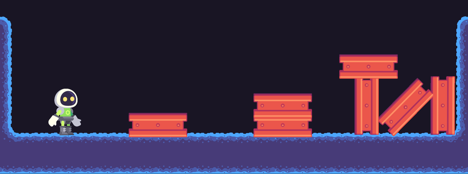

Making a player with a `RigidBody2D` is convenient as Godot handles gravity automatically. We couldn’t recommend it for all platformers, but using a `RigidBody2D` over a `KinematicBody2D` can work well for some action games like *Scribblenauts* and *Mount Your Friends*.

You can use a `RigidBody2D` in the *Character* mode for a platform game controller.

In this example, we use a *Physics Material Override* without any friction to stop gravity slowing your movement down as the physics engine pushes you into the floor.

*Contacts Reported* determines how many collisions Godot will pay attention to per frame. If this number isn’t high enough, we can miss collisions with the floor. Yet, we need them to know that the character is on the floor and can jump.

For a side-scrolling character in a game with curved terrain or slopes, you can set this number to at least `3` or `4`.

You can then use `RigidBody2D._integrate_forces()` to apply impulses or forces based on the player’s inputs.

```
export var speed := 6000.0
export var jump := 100000.0

func _integrate_forces(state: Physics2DDirectBodyState) -> void:
    # we calculate the player's horizontal direction.
    var direction := Input.get_action_strength("ui_right") - Input.get_action_strength("ui_left")

    # If the player is on the floor and they pressed the jump button add a jump
    # impulse.
    # See is_on_floor() below.
    if is_on_floor(state) and Input.is_action_pressed("shoot"):
        apply_central_impulse(Vector2.UP * jump * state.step)

    # We apply a horizontal force based on the input direction.
    apply_central_impulse(Vector2.RIGHT * direction * speed * state.step)
```

As `RigidBody2D` doesn’t have a convenient `is_on_floor()` function, unlike `KinematicBody2D`, we can code it ourselves.

```
func is_on_floor(state: Physics2DDirectBodyState) -> bool:
    # We check every collision reported. This depends on the contacts_reported
    # property and points of contact with the world.
    for contact in state.get_contact_count():
        # To know if we're on the floor, we check the collision normal. If the
        # normal vector roughly points up, we consider we're on the floor.
        var contact_normal := state.get_contact_local_normal(contact)
        # The vector dot product returns a value greater than 0 when two vectors
        # point in the same direction.
        # More precisely, the operation returns 0 when two vectors are
        # perpendicular and 1 when they're parallel.
        if contact_normal.dot(Vector2.UP) > 0.5:
            return true
    return false
```

### Make an explosion with forces

When making an explosion, you want objects and rubble to blast away from the origin. Rigid bodies are great for this as you can have the explosion apply an impulse to the objects in the blast radius.

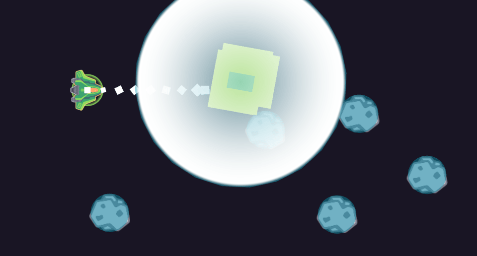

Your scene will have a lot more life if the world reacts to big forces like explosions. Using rigid bodies for the objects you want to send flying will let you dynamically apply forces to them.

In this example, we created an explosion animation attached to a rocket. The rocket itself is a `RigidBody2D`. With the *Contacts Reported* set to `1`, we detect when it collides with something and make it explode in reaction.

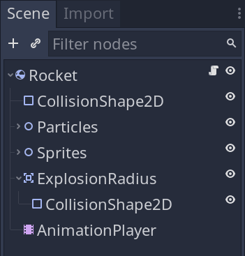

We handle the explosion with an animation.

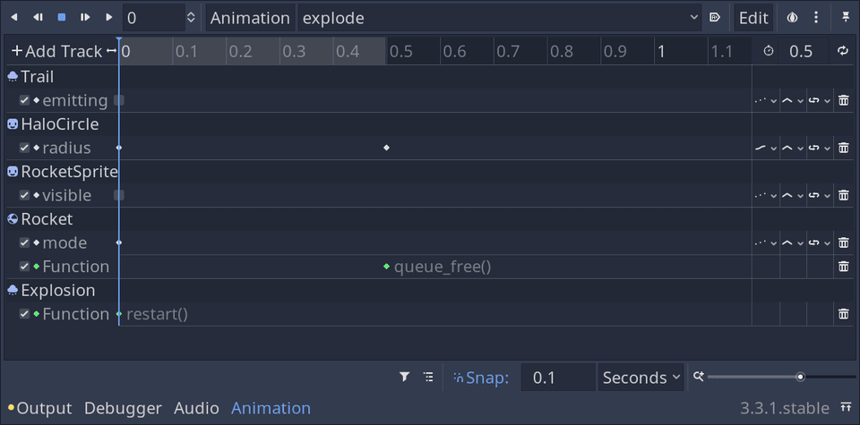

The animation:

- Hides some sprites and particles.
- Plays the *Explosion* particle system by calling the `Particles2D.restart()` built-in method.
- Changes the *Rocket*’s *Mode* to *Static* so it stops moving.
- Scales a halo circle up over time. This halo relies on a shader.

In the rocket’s code, we connect the `body_entered` to know when a collision occurred. And when it does, we call an `explode()` method.

```
class_name Rocket
extends RigidBody2D

## The maximum impulse we apply to bodies within the blast radius.
const BLAST_IMPULSE := 1500.0

onready var _animation_player: AnimationPlayer = $AnimationPlayer


func _ready() -> void:
    # We use the body_entered signal to detect when the rocket collides with
    # something.
    # When it does, we make it explode directly.
    connect("body_entered", self, "_on_body_entered")


func explode() -> void:
    # We first play the explode animation.
    _animation_player.play("explode")
    # We then get all bodies in the explosion area and loop over each.
    var colliders := _explosion_area.get_overlapping_bodies()
    for body in colliders:
        # If we detect a RigidBody2D, we can apply an impulse from the center of
        # the explosion to blast it outward.
        if body is RigidBody2D:
            var direction := global_position.direction_to(body.global_position)
            body.apply_central_impulse(BLAST_IMPULSE * direction)


func _on_body_entered(_body: Node) -> void:
    explode()
```

When the rocket touches a wall or another ship, it explodes, pushing everything away from it.

### Creating structures that collapse and fall over

Many games will want objects that react to physics. Be it boxes you push around, pressure plates, destructible terrain, or walls collapsing. Think of something like *Angry Birds*.

Here, we cover the example of a scene with a tower that you can knock over with a cannonball.

Clicking sends a projectile flying. When it touches the tower with the right trajectory, it causes it to fall apart.

[figure not shown]

With `RigidBody2D`, you get that almost for free. You just need both your projectile (the cannonball) and the structure to destroy to use rigid bodies.

You can set the starting velocity for a projectile with its `linear_velocity` property. Then, you can tweak other physics properties on towers to get the behavior you want.

Here’s how you can code the projectile itself. A separate player-controlled weapon instantiates the projectile, causing it to fire.

```
# The weapon that instances the cannonball sets this direction when instancing it.
var direction := Vector2.RIGHT

func _ready() -> void:
    # Making the projectile toplevel makes it move independently from its
    # parent.
    set_as_toplevel(true)
    # We give our projectile an initial velocity in the direction we fire it.
    linear_velocity = 1500 * direction
    look_at(direction)
```

For the structure, you want to create individual rigid bodies with a collision shape and place them in the editor.

[figure not shown]

These objects have many properties that let you fine-tune their behavior:

- The higher their *Mass*, the more velocity the cannonball will need to knock them down.
- If you want your bodies to fall faster, you can increase their *Gravity Scale* or add an applied force downwards via code.

For the cannonball, you can add a `PhysicsMaterial` to get access to more properties, such as *Bounce* and *Friction*.

We set our cannonball to have a *Bounce* of `0.5` to bounce on the structure upon hitting it.

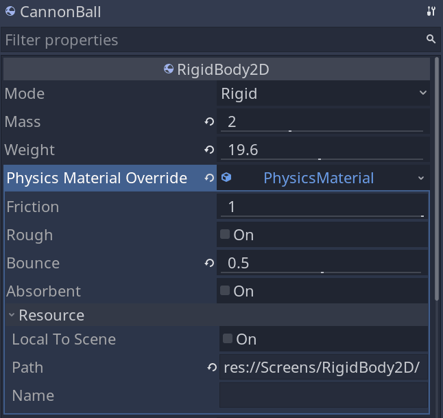

If your objects are rolling around too much, increase their *Angular Damping* property. This is very helpful for circular bodies that tend to rotate easily.

### Turning bodies into debris with the mode property

There are many objects you might want to have explode into tiny pieces and collide with physics. Examples include shattered glass, a splintering crate, or an enemy exploding into giblets.

[figure not shown]

Here, we have a ship explode into its core components on death, drift around the void of space and collide with the environment.

The ship is player-controlled until it takes too much damage and breaks apart. When that happens, we take control away from the player and send debris flying.

To do so, we have three rigid bodies for the main parts of the hull. By default, we set their *Mode* to *Kinematic* so they only follow the ship.

When the ship explodes, changing their *Mode* to *Rigid* allows us to give them an impulse to simulate them exploding out from the center.

[figure not shown]

To keep the player-controlled ship locked in place, when it dies, we change its `mode` to `RigidBody2D.MODE_KINEMATIC`.

We also change our original ship to *Kinematic* mode to stop it from moving. If your body and its fragments overlap, keep them in separate collision layers or deactivate the body’s collision shapes.

Here’s the code we use when the ship explodes.

```
onready var _sprite := $Sprite

# Called when the ship took too much damage.
func explode() -> void:
    # We hide the main ship's sprite. In the loop below, we made the debris
    # visible.
    _sprite.visible = false
    # We loop over all children. If they are rigid bodies, we give them an
    # impulse.
    for child in get_children():
        if child is RigidBody2D:
            # We make our components visible and rigid so they move under the
            # effect of physics.
            child.visible = true
            child.mode = MODE_RIGID
            # We apply an impulse in a random direction.
            child.apply_central_impulse(1000 * Vector2(rand_range(-1, 1), rand_range(-1, 1)))
    # Finally, we disable movement for our ship.
    mode = MODE_KINEMATIC
```

### Exploding polygons with code using Delaunay triangulation

There are many cases where you may want the shrapnel from your explosions to be in random shapes, or you want to avoid the legwork of manually creating giblets and chunks of spaceship hull.

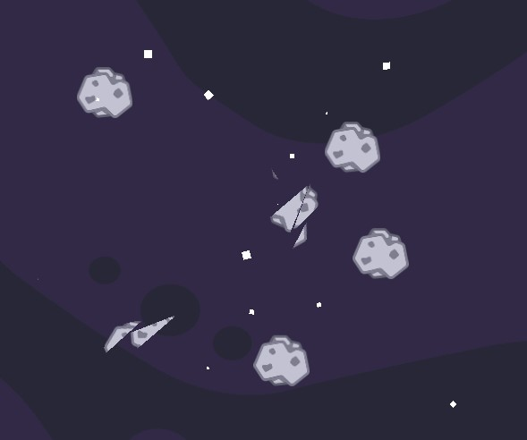

With the clever application of polygons, you can dynamically split your rigid bodies into shapes with just code using *Delaunay Triangulation*!

This function takes a polygon and returns a list of triangles that makes up that polygon. You can read a little more in the [official Geometry class documentation](https://docs.godotengine.org/en/stable/classes/class_geometry.html#class-geometry-method-triangulate-delaunay-2d), or even the [wikipedia page on Delaunay triangulation](https://en.wikipedia.org/wiki/Delaunay_triangulation) to dig deeper into the topic.

**Note:** This doesn’t generate new points; the function will return the indices of the points from your original polygon.

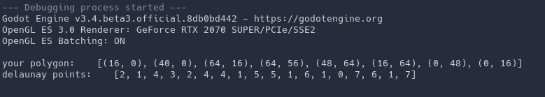

To make our polygon break into more pieces, we can add extra internal vertices.

For our example, we have asteroids exploding when the player clicks on them. So we will add the point where the player clicked as an extra vertex for more variety in our explosion.

We need two scenes to make this setup work: a `RigidBody2D` with a `CollisionPolygon` and a `Polygon2D` for the texture. This is the base for our base asteroid.

We then need another scene with the same structure to make the fragments of our asteroid.

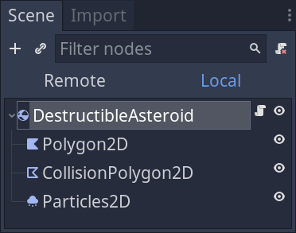

We need to use a `CollisionPolygon2D` rather than a `CollisionShape2D`, to use the `triangulate_delaunay_2d()` function.

In our asteroid, we need to define a packed scene to hold the asteroid fragment scene, and we need access to our two polygons.

```
export var _asteroid_fragment_scene: PackedScene

onready var _collision_polygon: CollisionPolygon2D = $CollisionPolygon2D
onready var _particles: Particles2D = $Particles2D
onready var _polygon: Polygon2D = $Polygon2D
```

Now, we can trigger our explosion with clicks by using the `_input_event()` virtual function and checking for clicks defined in our input map.

```
func _input_event(_viewport: Object, event: InputEvent, _shape_idx: int) -> void:
    if event.is_action_pressed("click"):
        explode(get_local_mouse_position())
```

Now we have the nuts and bolts of the explosion, using Delaunay triangulation.

We start by saving the polygon we want to explode. Once this is saved, we can add the origin of our explosion (where we clicked) to the polygon.

We can pass this polygon into the `triangulate_delaunay_2d()` function from the `Geometry` class. This function will return a `PoolIntArray`, of indices from our original polygon.

Every three indices make up a triangle. We can convert this data structure to a simple array using the `Array()` function to make it easier to handle.

We will need two for loops to handle this array, one iterating every three indices over each triangle and an interior loop over the three points in that triangle.

We will use the optional third parameter of the range function `step` to loop over each triangle.

```
range(0, delaunay_pointers.size(), 3)
```

This setup generates an array of points in the `delaunay_pointers` array, increasing in increments of `3`, like so:

`[0, 3, 6, 9, 12, 15, 18, 21, 24]`

Each of these indices will be the first point of each of our triangles.

The second will loop over the points in the triangle by taking advantage of the `slice()` function.

This function will return the values in an array between two indices to get just the points of our triangle.

```
delaunay_pointers.slice(pointer, pointer + 2)
```

We can create a new `PoolVector2Array` and save each point from the triangle into that to get our new polygon.

As mentioned earlier, to get the position of the point, we need to take the Delaunay index we have and use that to get the position from our original polygon like so:

```
delaunay_triangle.append(original_polygon[point])
```

We can wrap this up by instancing an asteroid shard scene and passing it the triangle polygon we just created.

```
## Split the asteroid polygon into smaller triangles and create
## AsteroidFragment instances.
func explode(origin: Vector2) -> void:
    var original_polygon = _polygon.polygon
    # Add an extra point to shatter at the point of impact. Adds destruction variation.
    original_polygon.append(origin)

    # Split the polygon into triangles using delaunay triangulation.
    # triangulate_delaunay_2d() returns a re-ordered list of indices (or
    # pointers) which can be used to get several triangles out of a polygon's
    # Vector2 points.
    var delaunay_pointers = Array(Geometry.triangulate_delaunay_2d(original_polygon))
    # Repeat for every group of three pointers.
    for pointer in range(0, delaunay_pointers.size(), 3):
        # Create a new triangle used for the fragment.
        var delaunay_triangle = PoolVector2Array()
        # Cycle through each of the three points that make up the triangle.
        for point in delaunay_pointers.slice(pointer, pointer + 2):
            # Add a Vector2 point from the original polygon to the new triangle.
            delaunay_triangle.append(original_polygon[point])
        # Create an asteroid fragment from the new triangle, using the same texture.
        var fragment = _asteroid_fragment_scene.instance()
        fragment.setup(delaunay_triangle, _polygon.texture)
        add_child(fragment)
```

The asteroid fragment doesn’t need to do a lot. Give that polygon to its `CollisionPolygon` and `Polygon2D` and launch itself in a random direction, and we’re done!

```
## Maximum force to shoot the fragment outward.
const MAX_FORCE := 666
## Minimum force to shoot the fragment outward.
const MIN_FORCE := 333

onready var _collision_polygon: CollisionPolygon2D = $CollisionPolygon2D
onready var _polygon: Polygon2D = $Polygon2D


## Gives the fragment its shape and appearance, sets a random velocity and
## direction.
func setup(polygon: PoolVector2Array, texture: Texture) -> void:
    # We call function before adding this node to the scene tree.
    yield(self, "ready")
    randomize()
    _collision_polygon.polygon = polygon
    _polygon.polygon = polygon
    _polygon.texture = texture
    linear_velocity = (
        rand_range(MIN_FORCE, MAX_FORCE)
        * Vector2.UP.rotated(rand_range(0, TAU))
    )
```

## Your questions

### When should I use a RigidBody2D over a KinematicBody2D?

Rigid bodies are great for an awful lot of things: ropes, fluids, traps, jump pads, motors, simple enemies, and much more.

Consider using a rigid body if your player exerts forces on or is forced by other bodies. In that case, you should consider using a rigid body for your player character.

They are also especially popular for mobile games like *Cut the Rope* and *Angry Birds*, as you can have lots happening with simple inputs. The concept of simple rules causing complex behaviors is also known as emergent gameplay.

### How can I make something float?

Using *Gravity Scale*, you can make any object float with ease. The *Gravity Scale* is a multiplier for the default gravity applied to a body. You can increase it to make a body fall faster.

Setting *Gravity Scale* to `0.0` will make an object float in place as no gravity acts on the body. You can take this a step further and put the *Gravity Scale* to `-1.0`.

A negative *Gravity Scale* will make an object fall upwards instead of falling to the ground and create objects like balloons. As this negative gravity exerts a force, you can use a pin joint to exert an upwards force on another body.

An alternative approach is to set the applied force of the balloon to be upwards and powerful enough to overcome the body’s gravity.

### What is sleeping?

When a body is asleep, it acts as a static body. Being asleep means the `_integrate_forces()` function will not run until a collision or code applies a force. Sleeping is excellent for reducing function calls if you have many rigid bodies.

The *Can Sleep* and *Sleeping* properties determine when a `RigidBody2D` goes to sleep. You can set the *Sleeping* property manually; it tells us if the body is currently asleep. The *Can Sleep* property tells us if the physics engine can automatically update the value of *Sleeping* after a duration at rest with no active forces.

The *Can Sleep* property updates *Sleeping* with the physics engine. Rigid bodies have the `sleeping_state_changed` signal for notifying you when the sleeping state of a body has changed.

**Note:** A body set to *Character* mode will never go to sleep automatically, but you can still set it manually.

### Can I scale my rigid body?

Don’t scale your rigid bodies! Instead, change the size of the shape directly.

Collision shapes easily break when you change their scale dynamically. Changing the scale of a physics body doesn’t apply any forces and will lead to unexpected behavior.

If you want to change the scale of a `PhysicsBody2D`, you should access the size values of your shape directly.

Another option is to create multiple collision shapes for a body and disable those not at the current size, enabling shapes and scaling the sprites separately.

There is room for unexpected behavior when changing the size of a body in too small a space. It is worth using one or more `RayCast2D` to detect if your body has enough space to expand.

### How can I figure out if a body will have a collision?

The `test_motion()` function returns `true` if a collision would occur after moving a given distance. The function takes a few optional parameters; in the simplest case, you should provide a `Vector2` indicating how you want the body to move.

The `test_motion()` function has three optional parameters:

1. `infinite_inertia` will make your collision ignore rigid bodies if set to true unless they are in static mode.
2. `margin` determines the size of shapes involved in collision detection. The larger this is, the less accurate the tested motion will be, but your calculation will be less performance intensive.
3. `result` is a `Physics2DTestMotionResult`. You can instance this object before passing it in. The function will update the result to contain details about any potential collisions. For example, it gives you the collision point, normal, and a reference to the colliding body.

```
var velocity := Vector2(100.0, 0.0)
# We need to define this motion result class to get information extra data back from the test_motion() function.
var motion_result := Physics2DTestMotionResult.new()
var will_collide := test_motion(velocity, true, 0.08, motion_result)
# printt() prints each argument separated by a tab character ("\t"), spacing them out.
printt(motion_result.motion_remainder, motion_result.collision_point)
```